# Imports

```python
from numpy import array, arange, zeros, transpose, cos, sin, arange, isfinite
from matplotlib import pyplot, rc
from math import pi
from IPython.display import Image, display
```

# ROMI NONLINEAR STATE SPACE EQUATIONS

**Outputs**

# Table of Romi Parameters

[ \begin{array}{llll} \hline \textbf{Variable} & \textbf{Units} & \textbf{Description} & \textbf{Estimated Value}\\ \hline K_{\omega} & \mathrm{rad}\,(\mathrm{V}^{-1}\mathrm{s}^{-1}) & \text{Motor speed constant} & 0.582\\ \tau_m & \mathrm{s} & \text{Motor time constant} & 0.10\\ u_L & \mathrm{V} & \text{Left motor command voltage} & 1.65\\ u_R & \mathrm{V} & \text{Right motor command voltage} & 1.82\\ r_w & \mathrm{cm} & \text{Wheel radius} & 3.5\\ b & \mathrm{cm} & \text{Track width (wheel--wheel)} & 15\\ N_g & {-} & \text{Gear ratio (motor:wheel)} & 1.0\\ V_{\max} & \mathrm{V} & \text{Voltage saturation limit} & 5.0\\ k_p & {-} & \text{PI proportional gain} & 0.6\\ k_i & \mathrm{s^{-1}} & \text{PI integral gain} & 4.0\\ v_{\mathrm{ref}}& \mathrm{cm\,s^{-1}} & \text{Desired linear speed setpoint} & 10\\ R_{\mathrm{ref}}& \mathrm{cm} & \text{Desired turning radius setpoint} & 200\\ \hline \end{array} ]

```python
# Electromechanical properties
K      = 250*2*pi/60/4.5     # Motor Gain [rad/(V*s)]
tau    = 0.1                 # Motor Time Constant [s]


# ---- Robot & motor parameters (define these once in your notebook) ----
r     = 3.5     # wheel radius [cm]
w     = 15      # track width [cm] (wheel-to-wheel distance)
K     = 25*2*pi/60/4.5   # motor speed gain [rad/(V*s)] used in first-order model
tau   = 0.10      # motor time constant [s]
N     = 1.0       # gear ratio if needed in your motor gain path (use 1.0 if not used)

u_l    = 1.65   # Left Motor Voltage [V]
u_r    = 1.82  # Right Motor Voltage [V]


Vmax  = 5.0       # voltage saturation [V]

# PI gains (tune)
Kp    = 0.6       # proportional gain on wheel-speed error
Ki    = 4.0       # integral gain on wheel-speed error

# Command shaping (can be constants or time-varying in your sim loop)
v_d   = 10      # desired forward speed [cm/s]
R_d   = 200  # desired turn radius [cm]; inf means straight
# -----------------------------------------------------------------------
```

## Open Loop System Model

```python
def system_eqn_OL(t, x):
    '''!@brief      Implements both state equations and output equations for the
                    open loop system
        @param t    The value of time for a given simulation step
        @param x    The value of the state vector for a given simulation step
        @return     A tuple containing both the derivative of the state vector
                    and the output vector for a given simulation step
    '''
    u = array([[u_l],
               [u_r]])  # choose u_l, u_r elsewhere (constants or functions)

    xd = array([[ (r/2)*(x[5,0]+x[4,0])*cos(x[2,0]) ],
                [ (r/2)*(x[5,0]+x[4,0])*sin(x[2,0]) ],
                [ (r/w)*(x[5,0]-x[4,0]) ],
                [ (r/2)*(x[5,0]+x[4,0]) ],
                [ (1/tau)*((K/N)*u[0,0] - x[4,0]) ],
                [ (1/tau)*((K/N)*u[1,0] - x[5,0]) ]])

    y = array([[ x[0,0] ],
               [ x[1,0] ],
               [ x[2,0] ],
               [ x[3,0] ],
               [ (r/2)*(x[5,0] + x[4,0]) ],
               [ (r/w)*(x[5,0] - x[4,0]) ]])

    return xd, y
```

## Closed Loop System Model

```python
def system_eqn_CL(t, x):
    '''!@brief      Implements both state equations and output equations for
                    the open loop system
        @param t    The value of time for a given simulation step
        @param x    The value of the state vector for a given simulation step
        @return     A tuple containing both the derivative of the state vector
                    and the output vector for a given simulation step
    '''

        # ------------------ Unpack state ------------------
    X_R   = x[0,0]     # world X position [m]
    Y_R   = x[1,0]     # world Y position [m]
    TH_R  = x[2,0]     # heading [rad]
    s     = x[3,0]     # path/arc variable (here we use forward distance)
    Om_L  = x[4,0]     # left wheel angular speed [rad/s]
    Om_R  = x[5,0]     # right wheel angular speed [rad/s]
    i_l   = x[6,0]     # integrator state (left)
    i_r   = x[7,0]     # integrator state (right)

    # ------------------ Kinematics targets ------------------
    # Convert (v_d, R_d) to desired body yaw rate omega_d.
    # If R_d is not finite or is ~0, interpret as "straight" (omega_d = 0).
    if isfinite(R_d) and abs(R_d) > 1e-6:
        omega_d = v_d / R_d
    else:
        omega_d = 0.0

    # Desired linear velocity at each wheel (m/s)
    vL_star = v_d - 0.5 * w * omega_d
    vR_star = v_d + 0.5 * w * omega_d

    # Desired wheel angular speeds (rad/s)
    OmL_star = vL_star / r
    OmR_star = vR_star / r

    # ------------------ Wheel-speed PI control ------------------
    # Errors in wheel speeds
    eL = OmL_star - Om_L
    eR = OmR_star - Om_R

    # PI control law (integrator states are i_l, i_r)
    uL = Kp * eL + i_l
    uR = Kp * eR + i_r

    # Voltage saturation
    if uL >  Vmax: uL =  Vmax
    if uL < -Vmax: uL = -Vmax
    if uR >  Vmax: uR =  Vmax
    if uR < -Vmax: uR = -Vmax

    # Anti-windup: stop integrating if saturated in the direction of the error
    if (uL >= Vmax and eL > 0) or (uL <= -Vmax and eL < 0):
        diL_dt = 0.0
    else:
        diL_dt = Ki * eL

    if (uR >= Vmax and eR > 0) or (uR <= -Vmax and eR < 0):
        diR_dt = 0.0
    else:
        diR_dt = Ki * eR

    # ------------------ Nonlinear robot dynamics ------------------
    # Body velocities from actual wheel speeds
    V_body     = 0.5 * r * (Om_R + Om_L)     # forward speed [m/s]
    Omega_body = (r / w) * (Om_R - Om_L)     # yaw rate [rad/s]

    # World-frame pose rates
    X_R_dot     = V_body * cos(TH_R)
    Y_R_dot     = V_body * sin(TH_R)
    Theta_R_dot = Omega_body

    # Path variable; choose definition.
    # If you want arc length forward, use avg wheel speed (sum):
    s_dot       = 0.5 * r * (Om_R + Om_L)
    # If you intended "lateral slip distance" or right-minus-left, switch to (Om_R - Om_L).

    # First-order DC motor model for wheel speeds
    # Note: include gear ratio N in the effective motor gain path if appropriate.
    Omega_L_dot = (1.0/tau) * ((K/N) * uL - Om_L)
    Omega_R_dot = (1.0/tau) * ((K/N) * uR - Om_R)

    # ------------------ Pack derivatives ------------------
    xd = array([[X_R_dot],
                [Y_R_dot],
                [Theta_R_dot],
                [s_dot],
                [Omega_L_dot],
                [Omega_R_dot],
                [diL_dt],
                [diR_dt]])

    # ------------------ Outputs ------------------
    y = array([[X_R],
               [Y_R],
               [TH_R],
               [s],
               [V_body],
               [Omega_body],
               [uL],
               [uR]])

    return xd, y
```

# Solvers

## Forward Euler Solver

For this example, as provided a simple solver will be implemented for you. That is, a first-order forward Euler solver is implemented below. It can be used as a template or example that you may extend to use a higher-order integration method, such as the Runge-Kutta method, see below for additional details.

The details of the solver will not be covered here in great depth, however it is important to understand the integration method in some depth to complete the assignment. The fundamental assumption used in a first-order solver is that over a small window of time the state of the system changes at a constant rate. That is, the derivative of the state vector, $\dot{\mathbf{x}}$, is assumed constant over a short window of time, $\Delta t$. This assumption leads directly to an integration algorithm called Euler's method. There are multiple formulations of Euler's method, and the simplest form is the Forward Euler method. The method predicts future states of the system based on knowledge of the present state and its derivative at a given instant in time. It is called a forward Euler method because it uses information at a given step $n$ to predict the future state at step $n+1$.

$$ \begin{array}{rl} \frac{\Delta \mathbf{x}}{\Delta t} &= \dot{\mathbf{x}}_n \\[2pt] \Delta \mathbf{x} &= \dot{\mathbf{x}}_n \Delta t \\[2pt] \mathbf{x}_{n+1} - \mathbf{x}_{n} &= \dot{\mathbf{x}}_n \Delta t \\[2pt] \mathbf{x}_{n+1} &= \mathbf{x}_{n} + \dot{\mathbf{x}}_n \Delta t \end{array} $$ where, $$ \begin{array}{rl} \dot{\mathbf{x}}_n &= \mathbf{f}(t,\mathbf{x}_n). \end{array} $$

```python
def Euler_solver(fcn, x_0, tspan, tstep):
    '''!@brief        Implements a first-order forward euler solver
        @param fcn    A function handle to the function to solve
        @param x_0    The initial value of the state vector
        @param tspan  A span of time over which to solve the system specified
                      as a list with two elements representing initial and
                      final time values
        @param tstep  The step size to use for the integration algorithm
        @return       A tuple containing both an array of time values and an
                      array of output values
    '''

    # Define a column of time values
    tout = arange(tspan[0], tspan[1]+tstep, tstep)

    # Preallocate an array of zeros to store state values
    xout = zeros([len(tout)+1,len(x_0)])

    # Determine the dimension of the output vector
    r = len(fcn(0,x_0)[1])

    # Preallocate an array of zeros to store output values
    yout = zeros([len(tout),r])

    # Initialize output array with intial state vector
    xout[0][:] = x_0.T

    # Iterate through the algorithm but stop one cycle early because
    # the algorithm predicts one cycle into the future
    for n in range(len(tout)):

        # Pull out a row from the solution array and transpose to get
        # the state vector as a column
        x = xout[[n]].T

        # Pull out the present value of time
        t = tout[n]

        # Evaluate the function handle at the present time with the
        # present value of the state vector to compute the derivative
        xd, y = fcn(t, x)

        # Apply the update rule for Euler's method. The derivative value
        # must be transposed back to a row here for the dimensions to line up.
        xout[n+1] = xout[n] + xd.T*tstep
        yout[n] = y.T

    return tout, yout
```

## Runge-Kutta Method (4th-order)

The following algorithm is presented without derivation, but is a marked improvement over Euler's method presented above. The integration technique is fourth-order, instead first-order, so has a much smaller truncation error for a given step size. Using an "RK" solver will allow you to use a much more reasonable step size and still get a solution of reasonable accuracy. The algorithm is similar to Euler's method, however it splits the window of time, $\Delta t$, in half and computes the derivative several times at the start of the time window, in the middle, and at the end. These derivatives are used to find a weighted average which is then used in a standard Euler step. $$ \begin{array}{rl} \mathbf{x}_{n+1} &= \mathbf{x}_{n} + \frac{1}{6} \left(\mathbf{k}_1 + 2 \mathbf{k}_2 + 2 \mathbf{k}_3 + \mathbf{k}_4 \right) \Delta t \end{array} $$ where, $$ \begin{array}{rll} \mathbf{k}_1 &= \mathbf{f}(t, & \mathbf{x}_n) \\[4pt] \mathbf{k}_2 &= \mathbf{f}(t+\frac{1}{2}\Delta t, & \mathbf{x}_n+\frac{1}{2} k_1 \Delta t) \\[4pt] \mathbf{k}_3 &= \mathbf{f}(t+\frac{1}{2}\Delta t, & \mathbf{x}_n+\frac{1}{2} k_2 \Delta t) \\[4pt] \mathbf{k}_4 &= \mathbf{f}(t+\Delta t, & \mathbf{x}_n+k_3 \Delta t). \end{array} $$

```python
def RK4_solver(fcn, x_0, tspan, tstep):
    '''!@brief        Implements a first-order forward euler solver
        @param fcn    A function handle to the function to solve
        @param x_0    The initial value of the state vector
        @param tspan  A span of time over which to solve the system specified
                      as a list with two elements representing initial and
                      final time values
        @param tstep  The step size to use for the integration algorithm
        @return       A tuple containing both an array of time values and an
                      array of output values
    '''
     # Define a column of time values
    tout = arange(tspan[0], tspan[1]+tstep, tstep)

    # Preallocate an array of zeros to store state values
    xout = zeros([len(tout)+1,len(x_0)])

    # Determine the dimension of the output vector
    r = len(fcn(0,x_0)[1])

    # Preallocate an array of zeros to store output values
    yout = zeros([len(tout),r])

    # Initialize output array with intial state vector
    xout[0][:] = x_0.T

    # Iterate through the algorithm but stop one cycle early because
    # the algorithm predicts one cycle into the future
    for n in range(len(tout)):

        # Pull out a row from the solution array and transpose to get
        # the state vector as a column
        x = xout[[n]].T

        # Pull out the present value of time
        t = tout[n]

        # Evaluate the function handle at the present time with the
        # present value of the state vector to compute forth order solution
        k_1, y =   fcn(t,x)
        k_2, y_2 = fcn(t+ 0.5*tstep , x + 0.5*k_1.T*tstep)
        k_3, y_3 = fcn(t+ 0.5*tstep , x + 0.5*k_2.T*tstep)
        k_4, y_4 = fcn(t + tstep , x + k_3.T*tstep)

        xout[n+1] = xout[n] + (1/6)*(k_1 + 2*k_2 + 2*k_3 + k_4).T*tstep
        yout[n] = y.T

    return tout, yout
```

# ROMI DYNAMICS: Running the Open-Loop Simulation

```python
# Similarly to the template, the following initial conditions will be used by both the open-loop and closed-loop simulations
x_0R = array([ [0],
               [0],
               [0],
               [0],
               [0],
               [0] ])
# Solve the open loop system over a 0.1 second time window with 1 us steps
#t_OL, y_OL = Euler_solver(system_eqn_OL, x_0, [0, 1], 1e-6)


#Instead Run the RK4 Solver for the Romi Dynamics
t_OL_R, y_OL_R= RK4_solver(system_eqn_OL, x_0R, [0, 200], 1e-4)
```

## ROMI DYNAMICS: Plotting the Open-Loop Simulation Results

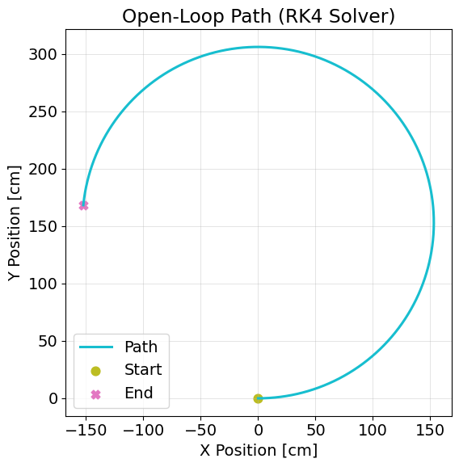

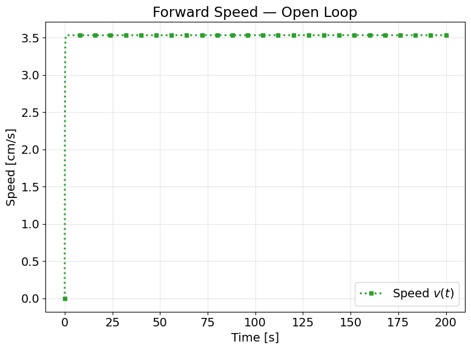

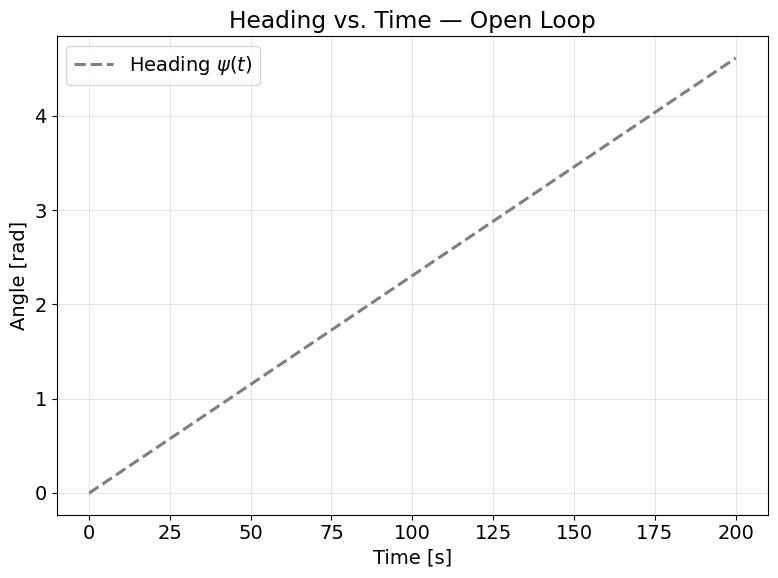

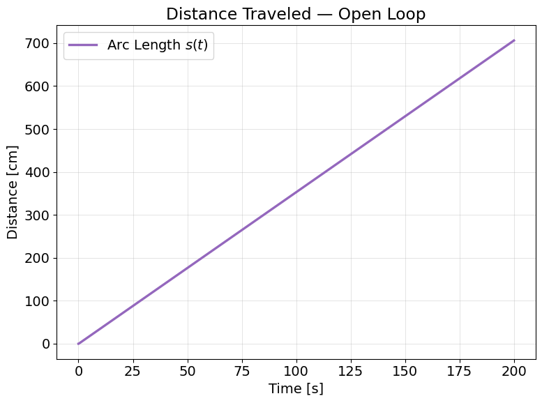

```python
rc('font', **{'size': 14})
pyplot.rcParams.update({
    "axes.grid": True,
    "grid.alpha": 0.35,
    "grid.linewidth": 0.7,
})

# 1) Trajectory (x–y)
pyplot.figure(figsize=(8,6))
pyplot.plot(y_OL_R[:,0], y_OL_R[:,1],
            color="tab:cyan", linewidth=2.2, linestyle="-", label="Path")
pyplot.scatter(y_OL_R[0,0],  y_OL_R[0,1],  s=60, color="tab:olive", marker="o", label="Start")
pyplot.scatter(y_OL_R[-1,0], y_OL_R[-1,1], s=60, color="tab:pink",  marker="X", label="End")
pyplot.gca().set_aspect("equal", adjustable="box")
pyplot.xlabel("X Position [cm]")
pyplot.ylabel("Y Position [cm]")
pyplot.title("Open-Loop Path (RK4 Solver)")
pyplot.legend(loc="best")
pyplot.tight_layout()

# 2) Forward speed v(t)
pyplot.figure(figsize=(8,6))
mark_every = max(len(t_OL_R)//25, 1)
pyplot.plot(t_OL_R, y_OL_R[:,4],
            color="tab:green", linestyle=":", linewidth=2.2,
            marker="s", markersize=4.5, markevery=mark_every,
            label="Speed $v(t)$")
pyplot.xlabel("Time [s]")
pyplot.ylabel("Speed [cm/s]")
pyplot.title("Forward Speed — Open Loop")
pyplot.legend(loc="best")
pyplot.tight_layout()

# 3) Heading angle ψ(t)
pyplot.figure(figsize=(8,6))
pyplot.plot(t_OL_R, y_OL_R[:,2],
            color="tab:gray", linestyle="--", linewidth=2.2,
            label=r"Heading $\psi(t)$")
pyplot.xlabel("Time [s]")
pyplot.ylabel("Angle [rad]")
pyplot.title("Heading vs. Time — Open Loop")
pyplot.legend(loc="best")
pyplot.tight_layout()

# 4) Arc length s(t)
pyplot.figure(figsize=(8,6))
pyplot.plot(t_OL_R, y_OL_R[:,3],
            color="tab:purple", linestyle="-", linewidth=2.4,
            label=r"Arc Length $s(t)$")
pyplot.xlabel("Time [s]")
pyplot.ylabel("Distance [cm]")
pyplot.title("Distance Traveled — Open Loop")
pyplot.legend(loc="best")
pyplot.tight_layout()
```

# ROMI DYNAMICS: Running the Closed-Loop Simulation

```python
# Solve the closed loop system over a 0.1 second time window with 1 us steps
# t_CL, y_CL = Euler_solver(system_eqn_CL, x_0, [0, 1], 1e-6)
x_0R_CL = array([[0],
                 [0],
                 [0],
                 [0],
                 [0],
                 [0],
                 [0],   # L
                 [0]])  # R
#Run the RK4 Solver for the Closed Loop instead
t_CLR, y_CLR = RK4_solver(system_eqn_CL, x_0R_CL, [0, 200], 1e-4)
```

# PRINT CLOSED LOOP STEADY STATE VALUES

```python
print(f"Left Motor Voltage: {y_CLR[-1,6]}")
print(f"Right Motor Voltage: {y_CLR[-1,7]}")
```

```
Left Motor Voltage: 4.726814922565292
Right Motor Voltage: 5.0
```

## ROMI DYNAMICS: Plotting the Closed-Loop Simulation Results

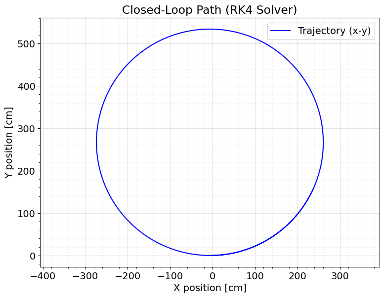

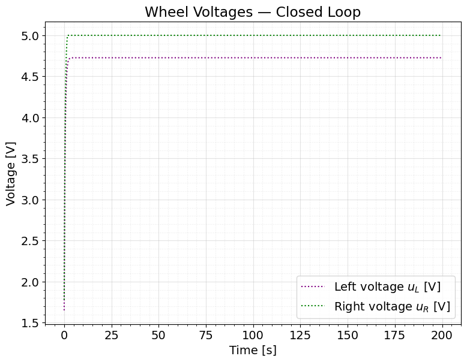

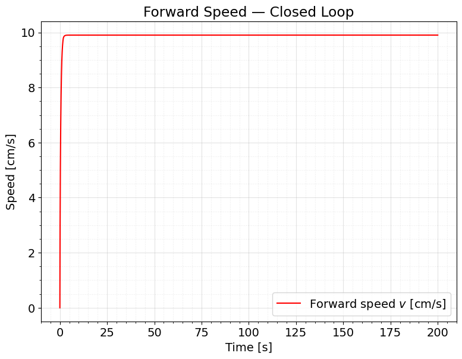

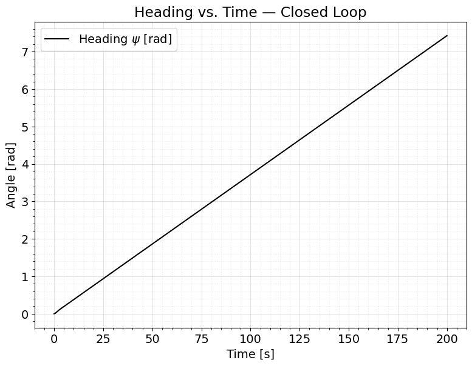

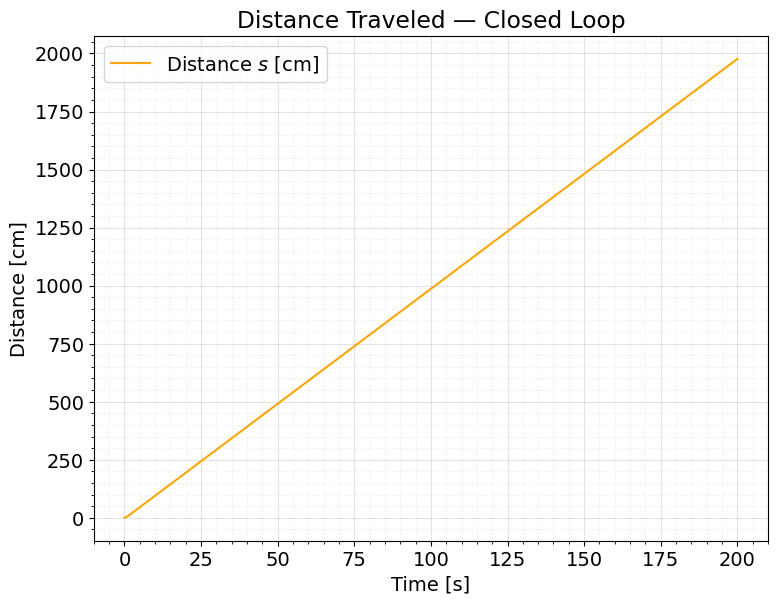

```python
pyplot.rcParams.update({"axes.grid": True,"grid.linewidth": 0.8,"grid.alpha": 0.35,})

T   = t_CLR           # time
X   = y_CLR[:,0]      # position x [cm]
Y   = y_CLR[:,1]      # position y [cm]
TH  = y_CLR[:,2]      # heading psi [rad]
S   = y_CLR[:,3]      # arc length [cm]
V   = y_CLR[:,4]      # forward speed [cm/s]
# y_CLR[:,5] is body yaw rate
uL  = y_CLR[:,6]      # left wheel voltage [V]
uR  = y_CLR[:,7]      # right wheel voltage [V]

# 1) Trajectory x–y
pyplot.figure(figsize=(8,6))
pyplot.plot(X, Y, color="blue")
pyplot.legend(["Trajectory (x-y)"])
pyplot.xlabel("X position [cm]")
pyplot.ylabel("Y position [cm]")
pyplot.minorticks_on()
pyplot.grid(True, which="major")
pyplot.grid(True, which="minor", linestyle=":", alpha=0.25)
pyplot.tight_layout()
pyplot.axis('equal')
pyplot.title("Closed-Loop Path (RK4 Solver)")

# 2) Wheel voltages u_L, u_R  (use same em-dash style)
pyplot.figure(figsize=(8,6))
pyplot.plot(T, uL, color="purple", linestyle=":")
pyplot.plot(T, uR, color="green",  linestyle=":")
pyplot.legend(["Left voltage $u_L$ [V]", "Right voltage $u_R$ [V]"])
pyplot.xlabel("Time [s]")
pyplot.ylabel("Voltage [V]")
pyplot.minorticks_on()
pyplot.grid(True, which="major")
pyplot.grid(True, which="minor", linestyle=":", alpha=0.25)
pyplot.tight_layout()
pyplot.title("Wheel Voltages — Closed Loop")

# 3) Forward speed v(t)
pyplot.figure(figsize=(8,6))
pyplot.plot(T, V, color="red")
pyplot.legend(["Forward speed $v$ [cm/s]"])
pyplot.xlabel("Time [s]")
pyplot.ylabel("Speed [cm/s]")
pyplot.minorticks_on()
pyplot.grid(True, which="major")
pyplot.grid(True, which="minor", linestyle=":", alpha=0.25)
pyplot.tight_layout()
pyplot.title("Forward Speed — Closed Loop")

# 4) Heading angle ψ(t)
pyplot.figure(figsize=(8,6))
pyplot.plot(T, TH, color="black")
pyplot.legend(["Heading $\\psi$ [rad]"])
pyplot.xlabel("Time [s]")
pyplot.ylabel("Angle [rad]")
pyplot.minorticks_on()
pyplot.grid(True, which="major")
pyplot.grid(True, which="minor", linestyle=":", alpha=0.25)
pyplot.tight_layout()
pyplot.title("Heading vs. Time — Closed Loop")

# 5) Arc length s(t)
pyplot.figure(figsize=(8,6))
pyplot.plot(T, S, color="orange")
pyplot.legend(["Distance $s$ [cm]"])
pyplot.xlabel("Time [s]")
pyplot.ylabel("Distance [cm]")
pyplot.minorticks_on()
pyplot.grid(True, which="major")
pyplot.grid(True, which="minor", linestyle=":", alpha=0.25)
pyplot.tight_layout()
pyplot.title("Distance Traveled — Closed Loop")
```